# PSI Week 10 Examples of Binary Logistic Regression

# Example 1

Trying to predict the likelihood of a student being admitted to graduate (postgraduate) school by grade point average, score on the GRE test and the academic ranking of the school where the student studied at undergraduate level Example adapted from https://rpubs.com/rslbliss/r_logistic_ws

```r
needed_packages <- c("foreign",  "Epi", "arm", "DescTools", "stargazer", "lmtest",  "car", "generalhoslem", "reshape2", "nnet", "ggplot2")
# Extract not installed packages
not_installed <- needed_packages[!(needed_packages %in% installed.packages()[ , "Package"])]
# Install not installed packages
if(length(not_installed)) install.packages(not_installed, repos = "http://cran.us.r-project.org")
```

```r
library(lmtest)
library(DescTools)
library(nnet)#Multinomial regression
library(foreign)
library(reshape2)
```

```r
library(ggplot2)
library(DescTools)
library(generalhoslem)#For test of fit for logistic regression
ldata <- read.csv("https://stats.idre.ucla.edu/stat/data/binary.csv")

#Data on admission to graduate programme
#admit- whether admitted or not
#gre - score on GRE test
#gpa - grade point average @ undergraduate degree
#rank - academic ranking of school where student took undergraduate degree
names(ldata)
```

```
## [1] "admit" "gre"   "gpa"   "rank"
```

```r
summary(ldata)
```

```
##      admit             gre             gpa             rank
##  Min.   :0.0000   Min.   :220.0   Min.   :2.260   Min.   :1.000
##  1st Qu.:0.0000   1st Qu.:520.0   1st Qu.:3.130   1st Qu.:2.000
##  Median :0.0000   Median :580.0   Median :3.395   Median :2.000
##  Mean   :0.3175   Mean   :587.7   Mean   :3.390   Mean   :2.485
##  3rd Qu.:1.0000   3rd Qu.:660.0   3rd Qu.:3.670   3rd Qu.:3.000
##  Max.   :1.0000   Max.   :800.0   Max.   :4.000   Max.   :4.000
```

```r
ldata$rank <- factor(ldata$rank)# Make sure that R treats this as a categorical variable
#We have FOUR categories of ranking
summary(ldata$rank)
```

```
##   1   2   3   4
##  61 151 121  67
```

## Create the logistic regression model

Can the likelihood of being admitted to a graduate programme be predicted by a students GRE score, gpa and the rank of the school where they took their undergraduate degree

```r
model <- glm(admit ~ gre + gpa + rank, data=ldata, family="binomial")
summary(model)
```

```
##
## Call:
## glm(formula = admit ~ gre + gpa + rank, family = "binomial",
##     data = ldata)
##
## Deviance Residuals:
##     Min       1Q   Median       3Q      Max
## -1.6268  -0.8662  -0.6388   1.1490   2.0790
##
## Coefficients:
##              Estimate Std. Error z value Pr(>|z|)
## (Intercept) -3.989979   1.139951  -3.500 0.000465 ***
## gre          0.002264   0.001094   2.070 0.038465 *
## gpa          0.804038   0.331819   2.423 0.015388 *
## rank2       -0.675443   0.316490  -2.134 0.032829 *
## rank3       -1.340204   0.345306  -3.881 0.000104 ***
## rank4       -1.551464   0.417832  -3.713 0.000205 ***
## ---
## Signif. codes:  0 '***' 0.001 '**' 0.01 '*' 0.05 '.' 0.1 ' ' 1
##
## (Dispersion parameter for binomial family taken to be 1)
##
##     Null deviance: 499.98  on 399  degrees of freedom
## Residual deviance: 458.52  on 394  degrees of freedom
## AIC: 470.52
##
## Number of Fisher Scoring iterations: 4
```

## Interpret the model

```r
# interpret logistic regression results,  transform the coefficients to odds ratios by raising e to the power of the coefficients.
# Store coefficients in another object
coefs <- coef(model)
# Show the coefficients, just for fun
coefs
```

```
##  (Intercept)          gre          gpa        rank2        rank3        rank4
## -3.989979073  0.002264426  0.804037549 -0.675442928 -1.340203916 -1.551463677
```

```r
#Raise e to the power of the coefficients to get the odds ratios
exp(coefs)
```

```
## (Intercept)         gre         gpa       rank2       rank3       rank4
##   0.0185001   1.0022670   2.2345448   0.5089310   0.2617923   0.2119375
```

```r
#We can do an additional transformation by taking the odds ratio, subtract 1, and multiply by 100 to get the percent change in the odds for a one unit increase in the independent variable.
# Doing the full transformation, all in one line
(exp(coefs)-1)*100
```

```
## (Intercept)         gre         gpa       rank2       rank3       rank4
## -98.1499899   0.2266992 123.4544824 -49.1069049 -73.8207721 -78.8062461
```

Co-efficient of gre = 1.0023: For a one point increase in GRE score, we expect to see a 0.23% increase in the odds of being admitted to graduate school. With a z-value of 2.07 and an associated p-value of 0.04, this coefficient is statistically significant at the 5% level. rank2 = 0.51: Doing your undergraduate degree in a school with a ranking of 2 compared to a rank 1 is associated with a 49% decrease in the odds of being admitted to graduate school. With a z-value of -2.134 and an associated p-value of 0.03, this coefficient is statistically significant at the 5% level.

## Assess the fit of the model

```r
#Chi-square plus significance
lmtest::lrtest(model)
```

|  | #Df | LogLik | Df | Chisq | Pr(>Chisq) |
| --- | --- | --- | --- | --- | --- |
| 1 | 6 | -229.2587 | NA | NA | NA |
| 2 | 1 | -249.9883 | -5 | 41.45903 | 7.578194e-08 |

```r
#Pseudo Rsquared plus Chi-square of the model
DescTools::PseudoR2(model, which="CoxSnell")
```

```
##   CoxSnell
## 0.09845702
```

```r
DescTools::PseudoR2(model, which="Nagelkerke")
```

```
## Nagelkerke
##  0.1379958
```

```r
#Check the assumption of linearity of independent variables and log odds using a Hosmer-Lemeshow test, if this is not statsitically significant we are ok
generalhoslem::logitgof(ldata$admit, fitted(model))
```

```
##
##  Hosmer and Lemeshow test (binary model)
##
## data:  ldata$admit, fitted(model)
## X-squared = 11.085, df = 8, p-value = 0.1969
```

```r
#Collinearity
vifmodel<-car::vif(model) # ignore any warnings, GVIF^(1/(2*Df)) is the value of interest
vifmodel
```

```
##          GVIF Df GVIF^(1/(2*Df))
## gre  1.134377  1        1.065071
## gpa  1.155902  1        1.075129
## rank 1.025759  3        1.004248
```

```r
#Tolerance
1/vifmodel
```

```
##           GVIF        Df GVIF^(1/(2*Df))
## gre  0.8815411 1.0000000       0.9389042
## gpa  0.8651255 1.0000000       0.9301212
## rank 0.9748878 0.3333333       0.9957702
```

The model is statistically significant It explains between 9.8% and 13.7% of the variance in likelihood of being admitted. So there is a lot that is not explained The assumption of linearity between independent variables and to log odds is met. Collinearity is not an issue.

# Example 2

Trying to predict the likelihood of the type of education programme a student is studying from the ses (social economic status) score and their score on a writing test Example adapted from https://stats.idre.ucla.edu/r/dae/multinomial-logistic-regression/

```r
mdata <- foreign::read.dta("https://stats.idre.ucla.edu/stat/data/hsbdemo.dta")

names(mdata)
```

```
##  [1] "id"      "female"  "ses"     "schtyp"  "prog"    "read"    "write"
##  [8] "math"    "science" "socst"   "honors"  "awards"  "cid"
```

```r
#prog is the type of educational programme (a categorical variable with three values)
#ses, a three-level categorical variable
#write is a continuous variable
with(mdata, table(ses, prog))
```

```
##         prog
## ses      general academic vocation
##   low         16       19       12
##   middle      20       44       31
##   high         9       42        7
```

```r
with(mdata, do.call(rbind, tapply(write, prog, function(x) c(M = mean(x), SD = sd(x)))))
```

```
##                 M       SD
## general  51.33333 9.397775
## academic 56.25714 7.943343
## vocation 46.76000 9.318754
```

## Build the model

```r
#Because prog has three levels we need to indicate which level is our reference
#We will be comparing the other types of programme to academic
mdata$prog2<-relevel(mdata$prog, ref = "academic")
```

```r
#We create the model using multinom
model2<-multinom(prog2~ses+write, data = mdata)
summary(model2)
```

```
## Call:
## multinom(formula = prog2 ~ ses + write, data = mdata)
##
## Coefficients:
##          (Intercept)  sesmiddle    seshigh      write
## general     2.852198 -0.5332810 -1.1628226 -0.0579287
## vocation    5.218260  0.2913859 -0.9826649 -0.1136037
##
## Std. Errors:
##          (Intercept) sesmiddle   seshigh      write
## general     1.166441 0.4437323 0.5142196 0.02141097
## vocation    1.163552 0.4763739 0.5955665 0.02221996
##
## Residual Deviance: 359.9635
## AIC: 375.9635
```

```r
#multinom package does not include p-value calculation for the regression coefficients, so we calculate p-values using Wald tests (here z-tests).
z <- summary(model2)$coefficients/summary(model2)$standard.errors
z
```

```
##          (Intercept)  sesmiddle   seshigh     write
## general     2.445214 -1.2018081 -2.261334 -2.705562
## vocation    4.484769  0.6116747 -1.649967 -5.112689
```

```r
p <- (1 - pnorm(abs(z), 0, 1)) * 2
p
```

```
##           (Intercept) sesmiddle    seshigh        write
## general  0.0144766100 0.2294379 0.02373856 6.818902e-03
## vocation 0.0000072993 0.5407530 0.09894976 3.176045e-07
```

```r
#Chi-square plus significance
lmtest::lrtest(model2)
```

|  | #Df | LogLik | Df | Chisq | Pr(>Chisq) |
| --- | --- | --- | --- | --- | --- |
| 1 | 8 | -179.9817 | NA | NA | NA |
| 2 | 2 | -204.0967 | -6 | 48.2299 | 1.063001e-08 |

```r
#Pseudo Rsquared

DescTools::PseudoR2(model2, which="CoxSnell")
```

```
##  CoxSnell
## 0.2142758
```

```r
DescTools::PseudoR2(model2, which="Nagelkerke")
```

```
## Nagelkerke
##  0.2462666
```

```r
#Check the assumption of linearity of independent variables and log odds using a Hosmer-Lemeshow test, if this is not statsitically significant we are ok
generalhoslem::logitgof(mdata$prog, fitted(model2))
```

```
##
##  Hosmer and Lemeshow test (multinomial model)
##
## data:  mdata$prog, fitted(model2)
## X-squared = 11.226, df = 16, p-value = 0.7953
```

```r
#Collinearity
vifmodel<-car::vif(model2)#You can ignore the warning messages, GVIF^(1/(2*Df)) is the value of interest
vifmodel
```

```
##            GVIF Df GVIF^(1/(2*Df))
## ses    4.366015  2        1.445511
## write 42.650682  1        6.530749
```

```r
#Tolerance
1/vifmodel
```

```
##             GVIF  Df GVIF^(1/(2*Df))
## ses   0.22904179 0.5       0.6917970
## write 0.02344628 1.0       0.1531218
```

Model is significant and explains between 21.43% and 24.63% of the variance No issue with assumption of linearity We may have problems with collinearity

## Interpret the model

```r
# interpret logistic regression results,  transform the coefficients to odds ratios by raising e to the power of the coefficients.

## extract the coefficients from the model and exponentiate
exp(coef(model2))
```

```
##          (Intercept) sesmiddle   seshigh     write
## general     17.32582 0.5866769 0.3126026 0.9437172
## vocation   184.61262 1.3382809 0.3743123 0.8926116
```

### The relative risk ratio for a one-unit increase in the variable write is .9437 for being in general program vs. academic program.

### The relative risk ratio switching from ses = 1 to 3 is .3126 for being in general program vs. academic program.

## Look at the predicted probabilities to understand the model

```r
#You can calculate predicted probabilities for each of our outcome levels using the fitted function
pp <- fitted(model2)

#If we want to examine the changes in predicted probability associated with one of our two variables, we can create small datasets varying one variable while holding the other constant. We will first do this holding write at its mean and examining the predicted probabilities for each level of ses.
dses <- data.frame(ses = c("low", "middle", "high"), write = mean(mdata$write))
predict(model2, newdata = dses, "probs")
```

```
##    academic   general  vocation
## 1 0.4396845 0.3581917 0.2021238
## 2 0.4777488 0.2283353 0.2939159
## 3 0.7009007 0.1784939 0.1206054
```

```r
#We can also use the predicted probabilities is to look at the averaged predicted probabilities for different values of the continuous predictor variable write within each level of ses.

dwrite <- data.frame(ses = rep(c("low", "middle", "high"), each = 41), write = rep(c(30:70),
    3))

## store the predicted probabilities for each value of ses and write
pp.write <- cbind(dwrite, predict(model2, newdata = dwrite, type = "probs", se = TRUE))

## calculate the mean probabilities within each level of ses
by(pp.write[, 3:5], pp.write$ses, colMeans)
```

```
## pp.write$ses: high
##  academic   general  vocation
## 0.6164315 0.1808037 0.2027648
## ------------------------------------------------------------
## pp.write$ses: low
##  academic   general  vocation
## 0.3972977 0.3278174 0.2748849
## ------------------------------------------------------------
## pp.write$ses: middle
##  academic   general  vocation
## 0.4256198 0.2010864 0.3732938
```

```r
#Using the predictions we generated for the pp.write object above, we can plot the predicted probabilities against the writing score by the level of ses for different levels of the outcome variable.

lpp <- reshape2::melt(pp.write, id.vars = c("ses", "write"), value.name = "probability")

head(lpp)  # view first few rows
```

|  | ses | write | variable | probability |
| --- | --- | --- | --- | --- |
| 1 | low | 30 | academic | 0.09843588 |
| 2 | low | 31 | academic | 0.10716868 |
| 3 | low | 32 | academic | 0.11650390 |
| 4 | low | 33 | academic | 0.12645834 |
| 5 | low | 34 | academic | 0.13704576 |
| 6 | low | 35 | academic | 0.14827643 |

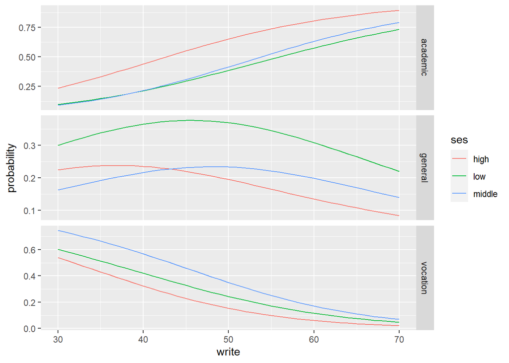

```r
## plot predicted probabilities across write values for each level of ses
## facetted by program type
ggplot(lpp, aes(x = write, y = probability, colour = ses)) + geom_line() + facet_grid(variable ~
    ., scales = "free")
```